# loan_defaulter_prediction_pre-processing

## REG_REGION_NOT_WORK_REGION

```python
dff[dff['REG_REGION_NOT_WORK_REGION'].isnull()==True]
```

|  | TARGET | NAME_CONTRACT_TYPE | CODE_GENDER | FLAG_OWN_CAR | FLAG_OWN_REALTY | CNT_CHILDREN | AMT_INCOME_TOTAL | AMT_CREDIT | AMT_ANNUITY | AMT_GOODS_PRICE | ... | AMT_REQ_CREDIT_BUREAU_MON | AMT_REQ_CREDIT_BUREAU_QRT | AMT_REQ_CREDIT_BUREAU_YEAR | LOG_AMT_INCOME_TOTAL | FLAG_DOC_SCORE | EXT_SOURCE_AVG | LOG_AMT_CREDIT | LOG_AMT_ANNUITY | LOG_AMT_GOODS_PRICE | CNT_FAM_MEMBERS_ |
| --- | --- | --- | --- | --- | --- | --- | --- | --- | --- | --- | --- | --- | --- | --- | --- | --- | --- | --- | --- | --- | --- |

0 rows × 81 columns

```python
dff['REG_REGION_NOT_WORK_REGION'].value_counts()
```

```
REG_REGION_NOT_WORK_REGION
0    291899
1     15612
Name: count, dtype: int64
```

```python
p=pd.crosstab(dff['REG_REGION_NOT_WORK_REGION'],dff['TARGET'])
p
```

| TARGET REG_REGION_NOT_WORK_REGION | 0 | 1 |
| --- | --- | --- |
| 0 | 268462 | 23437 |
| 1 | 14224 | 1388 |

```python
(dff.groupby('REG_REGION_NOT_WORK_REGION')['TARGET'].sum()/dff['REG_REGION_NOT_WORK_REGION'].value_counts())*100
```

```
REG_REGION_NOT_WORK_REGION
0    8.029147
1    8.890597
dtype: float64
```

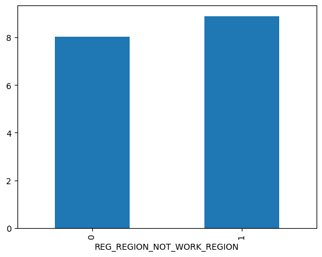

```python
(dff[dff['TARGET']==1]['REG_REGION_NOT_WORK_REGION'].value_counts()/dff['REG_REGION_NOT_WORK_REGION'].value_counts()*100).plot(kind='bar')
```

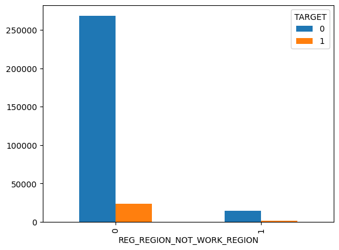

```python
pd.crosstab(dff['REG_REGION_NOT_WORK_REGION'],dff['TARGET']).plot(kind='bar')
```

HYPOTHESIS Ho : No relation between REG_REGION_NOT_WORK_REGION and TARGET columns Ha : Relationship exist between REG_REGION_NOT_WORK_REGION and TARGET columns

```python
stats.chi2_contingency(p)
```

```
Chi2ContingencyResult(statistic=14.703127021566337, pvalue=0.0001258375420219184, dof=1, expected_freq=array([[268334.33832936,  23564.66167064],
       [ 14351.66167064,   1260.33832936]]))
```

#### p-value 0.0001 < 0.05. Hence reject the null hypothesis.

#### Thus there is a significant relationship between REG_REGION_NOT_WORK_REGION and TARGET columns

### LIVE_REGION_NOT_WORK_REGION

```python
dff[dff['LIVE_REGION_NOT_WORK_REGION'].isnull()==True]
```

|  | TARGET | NAME_CONTRACT_TYPE | CODE_GENDER | FLAG_OWN_CAR | FLAG_OWN_REALTY | CNT_CHILDREN | AMT_INCOME_TOTAL | AMT_CREDIT | AMT_ANNUITY | AMT_GOODS_PRICE | ... | AMT_REQ_CREDIT_BUREAU_MON | AMT_REQ_CREDIT_BUREAU_QRT | AMT_REQ_CREDIT_BUREAU_YEAR | LOG_AMT_INCOME_TOTAL | FLAG_DOC_SCORE | EXT_SOURCE_AVG | LOG_AMT_CREDIT | LOG_AMT_ANNUITY | LOG_AMT_GOODS_PRICE | CNT_FAM_MEMBERS_ |
| --- | --- | --- | --- | --- | --- | --- | --- | --- | --- | --- | --- | --- | --- | --- | --- | --- | --- | --- | --- | --- | --- |

0 rows × 81 columns

```python
dff['LIVE_REGION_NOT_WORK_REGION'].value_counts()
```

```
LIVE_REGION_NOT_WORK_REGION
0    295008
1     12503
Name: count, dtype: int64
```

```python
q=pd.crosstab(dff['LIVE_REGION_NOT_WORK_REGION'],dff['TARGET'])
q
```

| TARGET LIVE_REGION_NOT_WORK_REGION | 0 | 1 |
| --- | --- | --- |
| 0 | 271239 | 23769 |
| 1 | 11447 | 1056 |

```python
(dff.groupby('LIVE_REGION_NOT_WORK_REGION')['TARGET'].sum()/dff['LIVE_REGION_NOT_WORK_REGION'].value_counts())*100
```

```
LIVE_REGION_NOT_WORK_REGION
0    8.057070
1    8.445973
dtype: float64
```

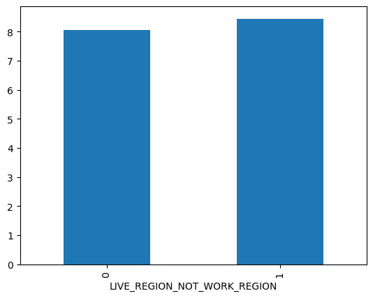

```python
(dff[dff['TARGET']==1]['LIVE_REGION_NOT_WORK_REGION'].value_counts()/dff['LIVE_REGION_NOT_WORK_REGION'].value_counts()*100).plot(kind='bar')
```

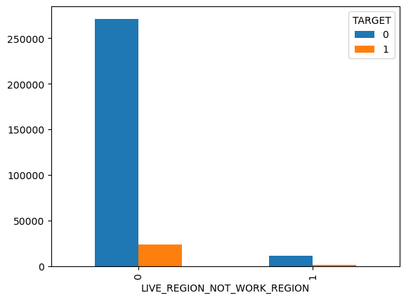

```python
pd.crosstab(dff['LIVE_REGION_NOT_WORK_REGION'],dff['TARGET']).plot(kind='bar')
```

HYPOTHESIS Ho : No relation between LIVE_REGION_NOT_WORK_REGION and TARGET columns Ha : Relationship exist between LIVE_REGION_NOT_WORK_REGION and TARGET columns

```python
stats.chi2_contingency(q)
```

```
Chi2ContingencyResult(statistic=2.3924235301789247, pvalue=0.12192447948152679, dof=1, expected_freq=array([[271192.35242967,  23815.64757033],
       [ 11493.64757033,   1009.35242967]]))
```

#### p-value 0.1 > 0.05. Hence failed to reject the null hypothesis.

#### Thus there is no significant relationship between LIVE_REGION_NOT_WORK_REGION and TARGET columns

### REG_CITY_NOT_LIVE_CITY

```python
dff[dff['REG_CITY_NOT_LIVE_CITY'].isnull()==True]
```

|  | TARGET | NAME_CONTRACT_TYPE | CODE_GENDER | FLAG_OWN_CAR | FLAG_OWN_REALTY | CNT_CHILDREN | AMT_INCOME_TOTAL | AMT_CREDIT | AMT_ANNUITY | AMT_GOODS_PRICE | ... | AMT_REQ_CREDIT_BUREAU_MON | AMT_REQ_CREDIT_BUREAU_QRT | AMT_REQ_CREDIT_BUREAU_YEAR | LOG_AMT_INCOME_TOTAL | FLAG_DOC_SCORE | EXT_SOURCE_AVG | LOG_AMT_CREDIT | LOG_AMT_ANNUITY | LOG_AMT_GOODS_PRICE | CNT_FAM_MEMBERS_ |
| --- | --- | --- | --- | --- | --- | --- | --- | --- | --- | --- | --- | --- | --- | --- | --- | --- | --- | --- | --- | --- | --- |

0 rows × 81 columns

```python
dff['REG_CITY_NOT_LIVE_CITY'].value_counts()
```

```
REG_CITY_NOT_LIVE_CITY
0    283472
1     24039
Name: count, dtype: int64
```

```python
r=pd.crosstab(dff['REG_CITY_NOT_LIVE_CITY'],dff['TARGET'])
r
```

| TARGET REG_CITY_NOT_LIVE_CITY | 0 | 1 |
| --- | --- | --- |
| 0 | 261586 | 21886 |
| 1 | 21100 | 2939 |

```python
(dff.groupby('REG_CITY_NOT_LIVE_CITY')['TARGET'].sum()/dff['REG_CITY_NOT_LIVE_CITY'].value_counts())*100
```

```
REG_CITY_NOT_LIVE_CITY
0     7.720692
1    12.225966
dtype: float64
```

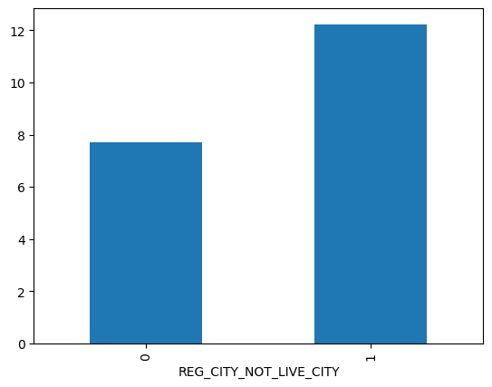

```python
(dff[dff['TARGET']==1]['REG_CITY_NOT_LIVE_CITY'].value_counts()/dff['REG_CITY_NOT_LIVE_CITY'].value_counts()*100).plot(kind='bar')
```

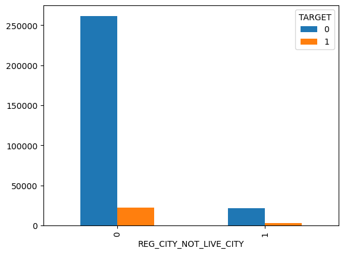

```python
pd.crosstab(dff['REG_CITY_NOT_LIVE_CITY'],dff['TARGET']).plot(kind='bar')
```

HYPOTHESIS Ho : No relation between REG_CITY_NOT_LIVE_CITY and TARGET columns Ha : Relationship exist between REG_CITY_NOT_LIVE_CITY and TARGET columns

```python
stats.chi2_contingency(r)
```

```
Chi2ContingencyResult(statistic=605.4816592205171, pvalue=1.0752352295806783e-133, dof=1, expected_freq=array([[260587.64009092,  22884.35990908],
       [ 22098.35990908,   1940.64009092]]))
```

#### p-value is very less (of the order of -133) and hence < 0.05. Hence reject the null hypothesis.

#### Thus there is a significant relationship between REG_CITY_NOT_LIVE_CITY and TARGET columns

### REG_CITY_NOT_WORK_CITY

```python
dff[dff['REG_CITY_NOT_WORK_CITY'].isnull()==True]
```

|  | TARGET | NAME_CONTRACT_TYPE | CODE_GENDER | FLAG_OWN_CAR | FLAG_OWN_REALTY | CNT_CHILDREN | AMT_INCOME_TOTAL | AMT_CREDIT | AMT_ANNUITY | AMT_GOODS_PRICE | ... | AMT_REQ_CREDIT_BUREAU_MON | AMT_REQ_CREDIT_BUREAU_QRT | AMT_REQ_CREDIT_BUREAU_YEAR | LOG_AMT_INCOME_TOTAL | FLAG_DOC_SCORE | EXT_SOURCE_AVG | LOG_AMT_CREDIT | LOG_AMT_ANNUITY | LOG_AMT_GOODS_PRICE | CNT_FAM_MEMBERS_ |
| --- | --- | --- | --- | --- | --- | --- | --- | --- | --- | --- | --- | --- | --- | --- | --- | --- | --- | --- | --- | --- | --- |

0 rows × 81 columns

```python
dff['REG_CITY_NOT_WORK_CITY'].value_counts()
```

```
REG_CITY_NOT_WORK_CITY
0    236644
1     70867
Name: count, dtype: int64
```

```python
s=pd.crosstab(dff['REG_CITY_NOT_WORK_CITY'],dff['TARGET'])
s
```

| TARGET REG_CITY_NOT_WORK_CITY | 0 | 1 |
| --- | --- | --- |
| 0 | 219339 | 17305 |
| 1 | 63347 | 7520 |

```python
(dff.groupby('REG_CITY_NOT_WORK_CITY')['TARGET'].sum()/dff['REG_CITY_NOT_WORK_CITY'].value_counts())*100
```

```
REG_CITY_NOT_WORK_CITY
0     7.312672
1    10.611427
dtype: float64
```

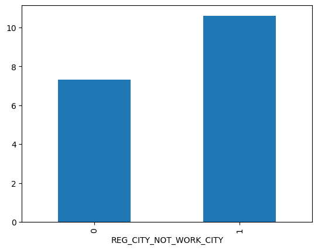

```python
(dff[dff['TARGET']==1]['REG_CITY_NOT_WORK_CITY'].value_counts()/dff['REG_CITY_NOT_WORK_CITY'].value_counts()*100).plot(kind='bar')
```

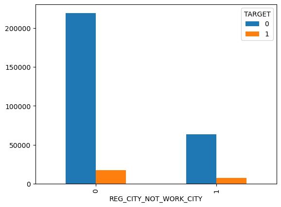

```python
pd.crosstab(dff['REG_CITY_NOT_WORK_CITY'],dff['TARGET']).plot(kind='bar')
```

HYPOTHESIS Ho : No relation between REG_CITY_NOT_WORK_CITY and TARGET columns Ha : Relationship exist between REG_CITY_NOT_WORK_CITY and TARGET columns

```python
stats.chi2_contingency(s)
```

```
Chi2ContingencyResult(statistic=799.2180447198825, pvalue=7.98127695863221e-176, dof=1, expected_freq=array([[217540.00924845,  19103.99075155],
       [ 65145.99075155,   5721.00924845]]))
```

### LIVE_CITY_NOT_WORK_CITY

```python
dff[dff['LIVE_CITY_NOT_WORK_CITY'].isnull()==True]
```

|  | TARGET | NAME_CONTRACT_TYPE | CODE_GENDER | FLAG_OWN_CAR | FLAG_OWN_REALTY | CNT_CHILDREN | AMT_INCOME_TOTAL | AMT_CREDIT | AMT_ANNUITY | AMT_GOODS_PRICE | ... | AMT_REQ_CREDIT_BUREAU_MON | AMT_REQ_CREDIT_BUREAU_QRT | AMT_REQ_CREDIT_BUREAU_YEAR | LOG_AMT_INCOME_TOTAL | FLAG_DOC_SCORE | EXT_SOURCE_AVG | LOG_AMT_CREDIT | LOG_AMT_ANNUITY | LOG_AMT_GOODS_PRICE | CNT_FAM_MEMBERS_ |
| --- | --- | --- | --- | --- | --- | --- | --- | --- | --- | --- | --- | --- | --- | --- | --- | --- | --- | --- | --- | --- | --- |

0 rows × 81 columns

```python
dff['LIVE_CITY_NOT_WORK_CITY'].value_counts()
```

```
LIVE_CITY_NOT_WORK_CITY
0    252296
1     55215
Name: count, dtype: int64
```

```python
t=pd.crosstab(dff['LIVE_CITY_NOT_WORK_CITY'],dff['TARGET'])
t
```

| TARGET LIVE_CITY_NOT_WORK_CITY | 0 | 1 |
| --- | --- | --- |
| 0 | 232974 | 19322 |
| 1 | 49712 | 5503 |

```python
(dff.groupby('LIVE_CITY_NOT_WORK_CITY')['TARGET'].sum()/dff['LIVE_CITY_NOT_WORK_CITY'].value_counts())*100
```

```
LIVE_CITY_NOT_WORK_CITY
0    7.658465
1    9.966495
dtype: float64
```

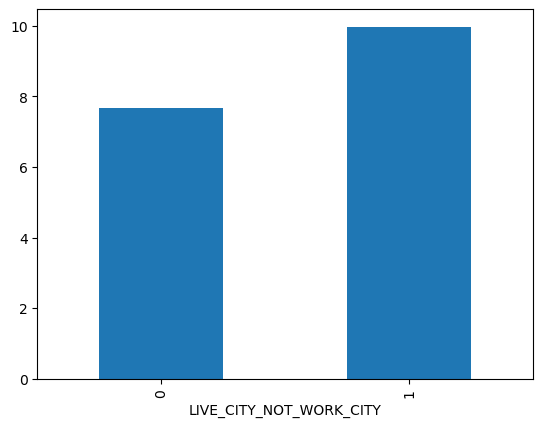

```python
(dff[dff['TARGET']==1]['LIVE_CITY_NOT_WORK_CITY'].value_counts()/dff['LIVE_CITY_NOT_WORK_CITY'].value_counts()*100).plot(kind='bar')
```

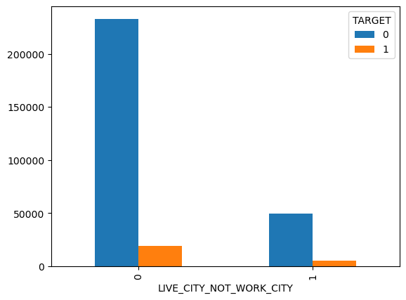

```python
pd.crosstab(dff['LIVE_CITY_NOT_WORK_CITY'],dff['TARGET']).plot(kind='bar')
```

HYPOTHESIS Ho : No relation between LIVE_CITY_NOT_WORK_CITY and TARGET columns Ha : Relationship exist between LIVE_CITY_NOT_WORK_CITY and TARGET columns

```python
stats.chi2_contingency(t)
```

```
Chi2ContingencyResult(statistic=324.86427113411753, pvalue=1.2629385266970663e-72, dof=1, expected_freq=array([[231928.44176631,  20367.55823369],
       [ 50757.55823369,   4457.44176631]]))
```

### OBS_30_CNT_SOCIAL_CIRCLE

```python
dff['OBS_30_CNT_SOCIAL_CIRCLE'].isnull().sum()
```

```
1021
```

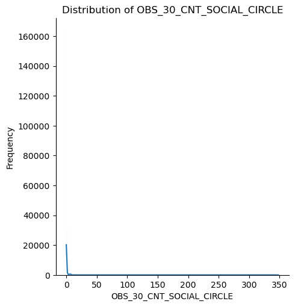

```python
sns.displot(dff['OBS_30_CNT_SOCIAL_CIRCLE'], kde=True)
plt.title('Distribution of OBS_30_CNT_SOCIAL_CIRCLE')
plt.xlabel('OBS_30_CNT_SOCIAL_CIRCLE')
plt.ylabel('Frequency')
plt.show()
```

```python
dff['OBS_30_CNT_SOCIAL_CIRCLE'].skew()
```

```
12.13959776486944
```

```python
dff['OBS_30_CNT_SOCIAL_CIRCLE'].value_counts()
```

```
OBS_30_CNT_SOCIAL_CIRCLE
0.0      163910
1.0       48783
2.0       29808
3.0       20322
4.0       14143
5.0        9553
6.0        6453
7.0        4390
8.0        2967
9.0        2003
10.0       1376
11.0        852
12.0        652
13.0        411
14.0        258
15.0        166
16.0        133
17.0         88
18.0         46
19.0         44
20.0         30
21.0         29
22.0         22
23.0         15
25.0         11
24.0         11
27.0          5
26.0          3
30.0          2
28.0          1
29.0          1
47.0          1
348.0         1
Name: count, dtype: int64
```

```python
li = []

for i in dff['OBS_30_CNT_SOCIAL_CIRCLE']:
    if i == 0.0:
        li.append('0')
    if i == 1.0:
        li.append('1')
    if i == 2.0:
        li.append('2')
    if i == 3.0:
        li.append('3')
    if i == 4.0:
        li.append('4')
    if i >= 5.0:
        li.append('greater than 4')

li1 = pd.Series(li)
dff['OBS_30_CNT_SOCIAL_CIRCLE'] = pd.DataFrame(li1)
dff['OBS_30_CNT_SOCIAL_CIRCLE'].value_counts()
```

```
OBS_30_CNT_SOCIAL_CIRCLE
0                 163910
1                  48783
2                  29808
greater than 4     29524
3                  20322
4                  14143
Name: count, dtype: int64
```

```python
o=pd.crosstab(dff['OBS_30_CNT_SOCIAL_CIRCLE'],dff['TARGET'])
o
```

| TARGET OBS_30_CNT_SOCIAL_CIRCLE | 0 | 1 |
| --- | --- | --- |
| 0 | 150666 | 13244 |
| 1 | 44777 | 4006 |
| 2 | 27410 | 2398 |
| 3 | 18698 | 1624 |
| 4 | 13036 | 1107 |
| greater than 4 | 27151 | 2373 |

```python
(dff.groupby('OBS_30_CNT_SOCIAL_CIRCLE')['TARGET'].sum()/dff['OBS_30_CNT_SOCIAL_CIRCLE'].value_counts())*100
```

```
OBS_30_CNT_SOCIAL_CIRCLE
0                 8.080044
1                 8.211877
2                 8.044820
3                 7.991339
4                 7.827194
greater than 4    8.037529
dtype: float64
```

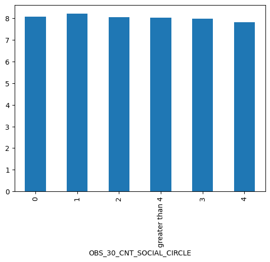

```python
(dff[dff['TARGET']==1]['OBS_30_CNT_SOCIAL_CIRCLE'].value_counts()/dff['OBS_30_CNT_SOCIAL_CIRCLE'].value_counts()*100).plot(kind='bar')
```

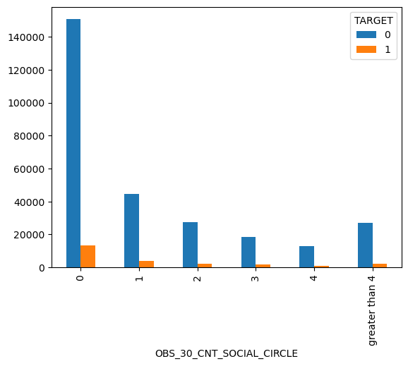

```python
pd.crosstab(dff['OBS_30_CNT_SOCIAL_CIRCLE'],dff['TARGET']).plot(kind='bar')
```

HYPOTHESIS Ho : No relation between OBS_30_CNT_SOCIAL_CIRCLE and TARGET columns Ha : Relationship exist between OBS_30_CNT_SOCIAL_CIRCLE and TARGET columns

```python
stats.chi2_contingency(o)
```

```
Chi2ContingencyResult(statistic=2.6902700744931387, pvalue=0.7476061795099317, dof=5, expected_freq=array([[150672.69920715,  13237.30079285],
       [ 44843.30599367,   3939.69400633],
       [ 27400.7187967 ,   2407.2812033 ],
       [ 18680.80405886,   1641.19594114],
       [ 13000.81742961,   1142.18257039],
       [ 27139.65451401,   2384.34548599]]))
```

### DEF_30_CNT_SOCIAL_CIRCLE

```python
dff['DEF_30_CNT_SOCIAL_CIRCLE'].isnull().sum()
```

```
1021
```

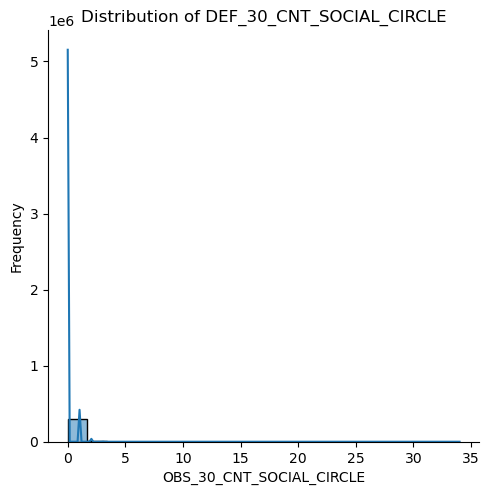

```python
sns.displot(dff['DEF_30_CNT_SOCIAL_CIRCLE'], kde=True)
plt.title('Distribution of DEF_30_CNT_SOCIAL_CIRCLE')
plt.xlabel('OBS_30_CNT_SOCIAL_CIRCLE')
plt.ylabel('Frequency')
plt.show()
```

```python
dff['DEF_30_CNT_SOCIAL_CIRCLE'] = pd.to_numeric(dff['DEF_30_CNT_SOCIAL_CIRCLE'], errors='coerce')

dff['DEF_30_CNT_SOCIAL_CIRCLE'].skew()
```

```
5.183517952420263
```

```python
dff['DEF_30_CNT_SOCIAL_CIRCLE'].value_counts()
```

```
DEF_30_CNT_SOCIAL_CIRCLE
0.0     271324
1.0      28328
2.0       5323
3.0       1192
4.0        253
5.0         56
6.0         11
7.0          1
34.0         1
8.0          1
Name: count, dtype: int64
```

```python
l = []

for i in dff['DEF_30_CNT_SOCIAL_CIRCLE']:
    if i == 0.0:
        l.append('0')
    if i == 1.0:
        l.append('1')
    if i == 2.0:
        l.append('2')
    if i >= 3.0:
        l.append('greater than 2')

lis = pd.Series(l)
dff['DEF_30_CNT_SOCIAL_CIRCLE'] = pd.DataFrame(lis)
dff['DEF_30_CNT_SOCIAL_CIRCLE'].value_counts()
```

```
DEF_30_CNT_SOCIAL_CIRCLE
0                 271324
1                  28328
2                   5323
greater than 2      1515
Name: count, dtype: int64
```

```python
o=pd.crosstab(dff['DEF_30_CNT_SOCIAL_CIRCLE'],dff['TARGET'])
o
```

| TARGET DEF_30_CNT_SOCIAL_CIRCLE | 0 | 1 |
| --- | --- | --- |
| 0 | 249395 | 21929 |
| 1 | 26081 | 2247 |
| 2 | 4866 | 457 |
| greater than 2 | 1396 | 119 |

```python
(dff.groupby('DEF_30_CNT_SOCIAL_CIRCLE')['TARGET'].sum()/dff['DEF_30_CNT_SOCIAL_CIRCLE'].value_counts())*100
```

```
DEF_30_CNT_SOCIAL_CIRCLE
0                 8.082219
1                 7.932081
2                 8.585384
greater than 2    7.854785
dtype: float64
```

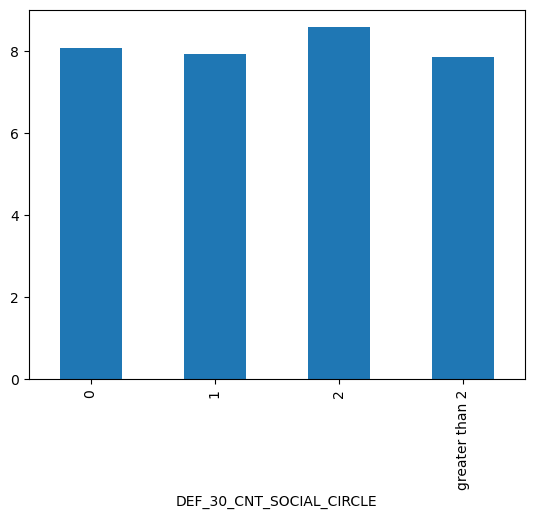

```python
(dff[dff['TARGET']==1]['DEF_30_CNT_SOCIAL_CIRCLE'].value_counts()/dff['DEF_30_CNT_SOCIAL_CIRCLE'].value_counts()*100).plot(kind='bar')
```

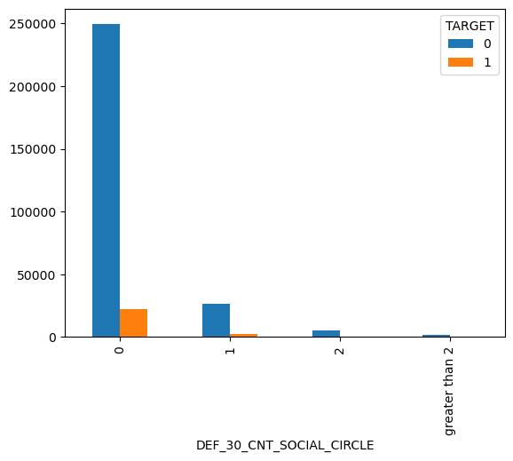

```python
pd.crosstab(dff['DEF_30_CNT_SOCIAL_CIRCLE'],dff['TARGET']).plot(kind='bar')
```

DEF_30_CNT_SOCIAL_CIRCLEHYPOTHESIS Ho : No relation between DEF_30_CNT_SOCIAL_CIRCLE and TARGET columns Ha : Relationship exist between DEF_30_CNT_SOCIAL_CIRCLE and TARGET columns

```python
stats.chi2_contingency(o)
```

```
Chi2ContingencyResult(statistic=2.7648412619445155, pvalue=0.4293204214821916, dof=3, expected_freq=array([[2.49411991e+05, 2.19120090e+04],
       [2.60402430e+04, 2.28775704e+03],
       [4.89311682e+03, 4.29883181e+02],
       [1.39264925e+03, 1.22350746e+02]]))
```

### DEF_60_CNT_SOCIAL_CIRCLE

```python
dff['DEF_60_CNT_SOCIAL_CIRCLE'].isnull().sum()
```

```
1021
```

```python
dff['DEF_60_CNT_SOCIAL_CIRCLE'].value_counts()
```

```
DEF_60_CNT_SOCIAL_CIRCLE
0.0     280721
1.0      21841
2.0       3170
3.0        598
4.0        135
5.0         20
6.0          3
7.0          1
24.0         1
Name: count, dtype: int64
```

```python
o=pd.crosstab(dff['DEF_60_CNT_SOCIAL_CIRCLE'],dff['TARGET'])
o
```

| TARGET DEF_60_CNT_SOCIAL_CIRCLE | 0 | 1 |
| --- | --- | --- |
| 0.0 | 258727 | 21994 |
| 1.0 | 19544 | 2297 |
| 2.0 | 2785 | 385 |
| 3.0 | 503 | 95 |
| 4.0 | 120 | 15 |
| 5.0 | 17 | 3 |
| 6.0 | 3 | 0 |
| 7.0 | 1 | 0 |
| 24.0 | 1 | 0 |

```python
(dff.groupby('DEF_60_CNT_SOCIAL_CIRCLE')['TARGET'].sum()/dff['DEF_60_CNT_SOCIAL_CIRCLE'].value_counts())*100
```

```
DEF_60_CNT_SOCIAL_CIRCLE
0.0      7.834825
1.0     10.516918
2.0     12.145110
3.0     15.886288
4.0     11.111111
5.0     15.000000
6.0      0.000000
7.0      0.000000
24.0     0.000000
dtype: float64
```

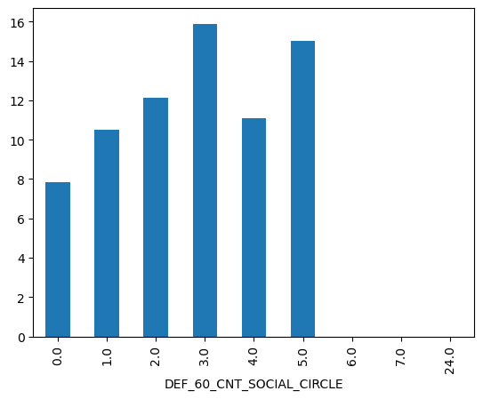

```python
(dff[dff['TARGET']==1]['DEF_60_CNT_SOCIAL_CIRCLE'].value_counts()/dff['DEF_60_CNT_SOCIAL_CIRCLE'].value_counts()*100).plot(kind='bar')
```

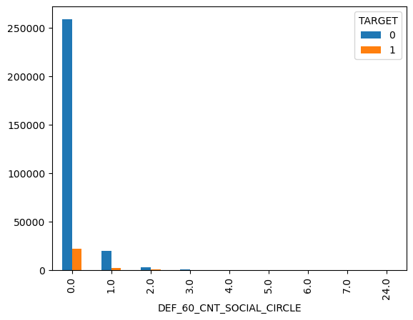

```python
pd.crosstab(dff['DEF_60_CNT_SOCIAL_CIRCLE'],dff['TARGET']).plot(kind='bar')
```

DEF_60_CNT_SOCIAL_CIRCLE Ho : No relation between DEF_60_CNT_SOCIAL_CIRCLE and TARGET columns Ha : Relationship exist between DEF_60_CNT_SOCIAL_CIRCLE and TARGET columns

```python
stats.chi2_contingency(o)
```

```
Chi2ContingencyResult(statistic=320.03391175971956, pvalue=2.228604964277652e-64, dof=8, expected_freq=array([[2.58016204e+05, 2.27047958e+04],
       [2.00744936e+04, 1.76650641e+03],
       [2.91360948e+03, 2.56390518e+02],
       [5.49633587e+02, 4.83664133e+01],
       [1.24081161e+02, 1.09188391e+01],
       [1.83823942e+01, 1.61760579e+00],
       [2.75735913e+00, 2.42640869e-01],
       [9.19119710e-01, 8.08802897e-02],
       [9.19119710e-01, 8.08802897e-02]]))
```

#### p-value is very less (of the order of -64) and hence < 0.05. Hence reject the null hypothesis.

#### Thus there is a significant relationship between DEF_60_CNT_SOCIAL_CIRCLE and TARGET columns

### DAYS_LAST_PHONE_CHANGE

```python
dff['DAYS_LAST_PHONE_CHANGE'].isnull().sum()
```

```
1
```

```python
dff['DAYS_LAST_PHONE_CHANGE']=abs(dff['DAYS_LAST_PHONE_CHANGE'])
```

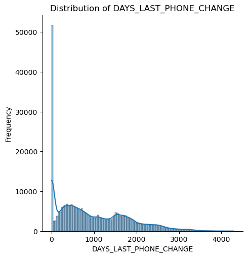

```python
sns.displot(dff['DAYS_LAST_PHONE_CHANGE'], kde=True)
plt.title('Distribution of DAYS_LAST_PHONE_CHANGE')
plt.xlabel('DAYS_LAST_PHONE_CHANGE')
plt.ylabel('Frequency')
plt.show()
```

```python
dff['DAYS_LAST_PHONE_CHANGE'].skew()
```

```
0.7136056678591622
```

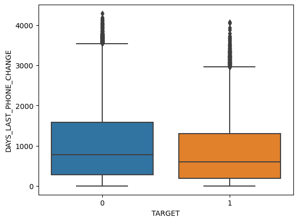

```python
sns.boxplot(y=dff['DAYS_LAST_PHONE_CHANGE'],x=dff['TARGET'])
```

```python
stats.shapiro(dff['DAYS_LAST_PHONE_CHANGE'])
```

```
ShapiroResult(statistic=nan, pvalue=1.0)
```

```python
pg.homoscedasticity(dff, dv='TARGET', group='DAYS_LAST_PHONE_CHANGE')
```

|  | W | pval | equal_var |
| --- | --- | --- | --- |
| levene | 1.14642 | 7.754117e-10 | False |

```python
default=dff[dff['TARGET']==1]['DAYS_LAST_PHONE_CHANGE']
nondefault=dff[dff['TARGET']==0]['DAYS_LAST_PHONE_CHANGE']
```

```python
len(default)
```

```
24825
```

```python
d1=default.sample(frac=1,random_state=42).reset_index(drop=True)
```

```python
nd1=np.random.choice(nondefault,size=24825,replace=False)
```

HYPOTHESIS Ho : No relation between DAYS_LAST_PHONE_CHANGE and TARGET columns Ha : Relationship exist between DAYS_LAST_PHONE_CHANGE and TARGET columns

```python
stats.mannwhitneyu(d1,nd1)
```

```
MannwhitneyuResult(statistic=271885744.5, pvalue=2.2142860256539755e-114)
```

## Dropping Columns

```python
dff.shape
```

```
(307511, 81)
```

```python
dff.info()
```

```
<class 'pandas.core.frame.DataFrame'>
RangeIndex: 307511 entries, 0 to 307510
Data columns (total 81 columns):
 #   Column                       Non-Null Count   Dtype
---  ------                       --------------   -----
 0   TARGET                       307511 non-null  int64
 1   NAME_CONTRACT_TYPE           307511 non-null  object
 2   CODE_GENDER                  307511 non-null  object
 3   FLAG_OWN_CAR                 307511 non-null  object
 4   FLAG_OWN_REALTY              307511 non-null  object
 5   CNT_CHILDREN                 307511 non-null  object
 6   AMT_INCOME_TOTAL             307511 non-null  float64
 7   AMT_CREDIT                   307511 non-null  float64
 8   AMT_ANNUITY                  307499 non-null  float64
 9   AMT_GOODS_PRICE              307233 non-null  float64
```

[output cut: 73 more lines]

```python
# dff['FLAG_EMP_PHONE'] = dff['FLAG_EMP_PHONE'].astype('object')
dff['FLAG_EMP_PHONE'] = dff['FLAG_EMP_PHONE'].astype('object')
dff['FLAG_WORK_PHONE'] = dff['FLAG_WORK_PHONE'].astype('object')
dff['FLAG_CONT_MOBILE'] = dff['FLAG_CONT_MOBILE'].astype('object')
dff['FLAG_PHONE'] = dff['FLAG_PHONE'].astype('object')
dff['FLAG_EMAIL'] = dff['FLAG_EMAIL'].astype('object')

dff['REGION_RATING_CLIENT'] = dff['REGION_RATING_CLIENT'].astype('object')
dff['REGION_RATING_CLIENT_W_CITY'] = dff['REGION_RATING_CLIENT_W_CITY'].astype('object')
dff['REG_REGION_NOT_LIVE_REGION'] = dff['REG_REGION_NOT_LIVE_REGION'].astype('object')
dff['REG_REGION_NOT_WORK_REGION'] = dff['REG_REGION_NOT_WORK_REGION'].astype('object')
dff['LIVE_REGION_NOT_WORK_REGION'] = dff['LIVE_REGION_NOT_WORK_REGION'].astype('object')

dff['REG_CITY_NOT_LIVE_CITY'] = dff['REG_CITY_NOT_LIVE_CITY'].astype('object')
dff['REG_CITY_NOT_WORK_CITY'] = dff['REG_CITY_NOT_WORK_CITY'].astype('object')
dff['LIVE_CITY_NOT_WORK_CITY'] = dff['LIVE_CITY_NOT_WORK_CITY'].astype('object')

dff['DEF_60_CNT_SOCIAL_CIRCLE'] = dff['DEF_60_CNT_SOCIAL_CIRCLE'].astype('object')
```

```python
dff.info()
```

```
<class 'pandas.core.frame.DataFrame'>
RangeIndex: 307511 entries, 0 to 307510
Data columns (total 81 columns):
 #   Column                       Non-Null Count   Dtype
---  ------                       --------------   -----
 0   TARGET                       307511 non-null  int64
 1   NAME_CONTRACT_TYPE           307511 non-null  object
 2   CODE_GENDER                  307511 non-null  object
 3   FLAG_OWN_CAR                 307511 non-null  object
 4   FLAG_OWN_REALTY              307511 non-null  object
 5   CNT_CHILDREN                 307511 non-null  object
 6   AMT_INCOME_TOTAL             307511 non-null  float64
 7   AMT_CREDIT                   307511 non-null  float64
 8   AMT_ANNUITY                  307499 non-null  float64
 9   AMT_GOODS_PRICE              307233 non-null  float64
```

[output cut: 73 more lines]

```python
dff.drop('FLAG_MOBIL', axis = 1 , inplace = True)
```

```python
dff.drop('CNT_FAM_MEMBERS' , axis = 1 , inplace = True)
```

```python
dff.drop(['AMT_INCOME_TOTAL','AMT_CREDIT','AMT_ANNUITY','AMT_GOODS_PRICE','DAYS_LAST_PHONE_CHANGE'], axis =1 , inplace = True)
```

```python
dff.drop(ext.columns , axis = 1 , inplace = True)
```

```python
dff.drop(document.columns , axis = 1 , inplace = True)
```

```python
dff.describe(include = object)
```

|  | NAME_CONTRACT_TYPE | CODE_GENDER | FLAG_OWN_CAR | FLAG_OWN_REALTY | CNT_CHILDREN | NAME_TYPE_SUITE | NAME_INCOME_TYPE | NAME_EDUCATION_TYPE | NAME_FAMILY_STATUS | NAME_HOUSING_TYPE | ... | REG_REGION_NOT_WORK_REGION | LIVE_REGION_NOT_WORK_REGION | REG_CITY_NOT_LIVE_CITY | REG_CITY_NOT_WORK_CITY | LIVE_CITY_NOT_WORK_CITY | ORGANIZATION_TYPE | OBS_30_CNT_SOCIAL_CIRCLE | DEF_30_CNT_SOCIAL_CIRCLE | DEF_60_CNT_SOCIAL_CIRCLE | CNT_FAM_MEMBERS_ |
| --- | --- | --- | --- | --- | --- | --- | --- | --- | --- | --- | --- | --- | --- | --- | --- | --- | --- | --- | --- | --- | --- |
| count | 307511 | 307511 | 307511 | 307511 | 307511 | 306219 | 307511 | 307511 | 307511 | 307511 | ... | 307511 | 307511 | 307511 | 307511 | 307511 | 307511 | 306490 | 306490 | 306490.0 | 307509 |
| unique | 2 | 2 | 2 | 2 | 4 | 7 | 8 | 5 | 6 | 6 | ... | 2 | 2 | 2 | 2 | 2 | 15 | 6 | 4 | 9.0 | 2 |
| top | Cash loans | F | N | Y | 0 | Unaccompanied | Working | Secondary / secondary special | Married | House / apartment | ... | 0 | 0 | 0 | 0 | 0 | Business/Self-employed | 0 | 0 | 0.0 | small family |
| freq | 278232 | 202452 | 202924 | 213312 | 215371 | 248526 | 158774 | 218391 | 196432 | 272868 | ... | 291899 | 295008 | 283472 | 236644 | 252296 | 122941 | 163910 | 271324 | 280721.0 | 303502 |

4 rows × 31 columns

```python
document.columns
```

```
Index(['FLAG_DOCUMENT_2', 'FLAG_DOCUMENT_3', 'FLAG_DOCUMENT_4',
       'FLAG_DOCUMENT_5', 'FLAG_DOCUMENT_6', 'FLAG_DOCUMENT_7',
       'FLAG_DOCUMENT_8', 'FLAG_DOCUMENT_9', 'FLAG_DOCUMENT_10',
       'FLAG_DOCUMENT_11', 'FLAG_DOCUMENT_12', 'FLAG_DOCUMENT_13',
       'FLAG_DOCUMENT_14', 'FLAG_DOCUMENT_15', 'FLAG_DOCUMENT_16',
       'FLAG_DOCUMENT_17', 'FLAG_DOCUMENT_18', 'FLAG_DOCUMENT_19',
       'FLAG_DOCUMENT_20', 'FLAG_DOCUMENT_21'],
      dtype='object')
```

# KNN

```python
dff.info()
```

```
<class 'pandas.core.frame.DataFrame'>
RangeIndex: 307511 entries, 0 to 307510
Data columns (total 51 columns):
 #   Column                       Non-Null Count   Dtype
---  ------                       --------------   -----
 0   TARGET                       307511 non-null  int64
 1   NAME_CONTRACT_TYPE           307511 non-null  object
 2   CODE_GENDER                  307511 non-null  object
 3   FLAG_OWN_CAR                 307511 non-null  object
 4   FLAG_OWN_REALTY              307511 non-null  object
 5   CNT_CHILDREN                 307511 non-null  object
 6   NAME_TYPE_SUITE              306219 non-null  object
 7   NAME_INCOME_TYPE             307511 non-null  object
 8   NAME_EDUCATION_TYPE          307511 non-null  object
 9   NAME_FAMILY_STATUS           307511 non-null  object
```

[output cut: 43 more lines]

```python
dff['OCCUPATION_TYPE'].value_counts()
```

```
Laborers                  57279
retired                   55372
Services staff            48460
HR Finance & Marketing    43229
Core staff                27570
Managers                  21371
Technical staff           11906
Secretaries                1305
Name: OCCUPATION_TYPE, dtype: int64
```

```python
dff.shape
```

```
(307511, 51)
```

```python
df99=pd.get_dummies(dff , drop_first = True)
```

```python
df99.shape
```

```
(307511, 115)
```

```python
df99.info(max_cols = 120)
```

```
<class 'pandas.core.frame.DataFrame'>
RangeIndex: 307511 entries, 0 to 307510
Data columns (total 115 columns):
 #    Column                                             Non-Null Count   Dtype
---   ------                                             --------------   -----
 0    TARGET                                             307511 non-null  int64
 1    REGION_POPULATION_RELATIVE                         307511 non-null  float64
 2    DAYS_BIRTH                                         307511 non-null  int64
 3    DAYS_EMPLOYED                                      307511 non-null  float64
 4    DAYS_REGISTRATION                                  307511 non-null  float64
 5    DAYS_ID_PUBLISH                                    307511 non-null  int64
 6    OWN_CAR_AGE                                        307506 non-null  float64
 7    OBS_60_CNT_SOCIAL_CIRCLE                           306490 non-null  float64
 8    AMT_REQ_CREDIT_BUREAU_HOUR                         265992 non-null  float64
 9    AMT_REQ_CREDIT_BUREAU_DAY                          265992 non-null  float64
```

[output cut: 107 more lines]

```python
df_x=df99.drop('TARGET',axis=1)
```

```python
df_x.head()
```

|  | REGION_POPULATION_RELATIVE | DAYS_BIRTH | DAYS_EMPLOYED | DAYS_REGISTRATION | DAYS_ID_PUBLISH | OWN_CAR_AGE | OBS_60_CNT_SOCIAL_CIRCLE | AMT_REQ_CREDIT_BUREAU_HOUR | AMT_REQ_CREDIT_BUREAU_DAY | AMT_REQ_CREDIT_BUREAU_WEEK | ... | DEF_30_CNT_SOCIAL_CIRCLE_greater than 2 | DEF_60_CNT_SOCIAL_CIRCLE_1.0 | DEF_60_CNT_SOCIAL_CIRCLE_2.0 | DEF_60_CNT_SOCIAL_CIRCLE_3.0 | DEF_60_CNT_SOCIAL_CIRCLE_4.0 | DEF_60_CNT_SOCIAL_CIRCLE_5.0 | DEF_60_CNT_SOCIAL_CIRCLE_6.0 | DEF_60_CNT_SOCIAL_CIRCLE_7.0 | DEF_60_CNT_SOCIAL_CIRCLE_24.0 | CNT_FAM_MEMBERS__small family |
| --- | --- | --- | --- | --- | --- | --- | --- | --- | --- | --- | --- | --- | --- | --- | --- | --- | --- | --- | --- | --- | --- |
| 0 | 0.137117 | -9461 | -637.0 | 60.398675 | -2120 | -1.0 | 2.0 | 0.0 | 0.0 | 0.0 | ... | 0 | 0 | 1 | 0 | 0 | 0 | 0 | 0 | 0 | 1 |
| 1 | 0.059506 | -16765 | -1188.0 | 34.438351 | -291 | -1.0 | 1.0 | 0.0 | 0.0 | 0.0 | ... | 0 | 0 | 0 | 0 | 0 | 0 | 0 | 0 | 0 | 1 |
| 2 | 0.100160 | -19046 | -225.0 | 65.268675 | -2531 | 26.0 | 0.0 | 0.0 | 0.0 | 0.0 | ... | 0 | 0 | 0 | 0 | 0 | 0 | 0 | 0 | 0 | 1 |
| 3 | 0.089549 | -19005 | -3039.0 | 99.161484 | -2437 | -1.0 | 2.0 | NaN | NaN | NaN | ... | 0 | 0 | 0 | 0 | 0 | 0 | 0 | 0 | 0 | 1 |
| 4 | 0.169302 | -19932 | -3038.0 | 65.658206 | -3458 | -1.0 | 0.0 | 0.0 | 0.0 | 0.0 | ... | 0 | 0 | 0 | 0 | 0 | 0 | 0 | 0 | 0 | 1 |

5 rows × 114 columns

```python
from sklearn.impute import KNNImputer
```

```python
knn=KNNImputer(n_neighbors=3)
```

```python
df120=df_x.loc[0:50000]
df_imp1 = pd.DataFrame(knn.fit_transform(df120) , columns = df120.columns)
```

```python
df_imp1
```

|  | REGION_POPULATION_RELATIVE | DAYS_BIRTH | DAYS_EMPLOYED | DAYS_REGISTRATION | DAYS_ID_PUBLISH | OWN_CAR_AGE | OBS_60_CNT_SOCIAL_CIRCLE | AMT_REQ_CREDIT_BUREAU_HOUR | AMT_REQ_CREDIT_BUREAU_DAY | AMT_REQ_CREDIT_BUREAU_WEEK | ... | DEF_30_CNT_SOCIAL_CIRCLE_greater than 2 | DEF_60_CNT_SOCIAL_CIRCLE_1.0 | DEF_60_CNT_SOCIAL_CIRCLE_2.0 | DEF_60_CNT_SOCIAL_CIRCLE_3.0 | DEF_60_CNT_SOCIAL_CIRCLE_4.0 | DEF_60_CNT_SOCIAL_CIRCLE_5.0 | DEF_60_CNT_SOCIAL_CIRCLE_6.0 | DEF_60_CNT_SOCIAL_CIRCLE_7.0 | DEF_60_CNT_SOCIAL_CIRCLE_24.0 | CNT_FAM_MEMBERS__small family |
| --- | --- | --- | --- | --- | --- | --- | --- | --- | --- | --- | --- | --- | --- | --- | --- | --- | --- | --- | --- | --- | --- |
| 0 | 0.137117 | -9461.0 | -637.0 | 60.398675 | -2120.0 | -1.0 | 2.0 | 0.0 | 0.0 | 0.0 | ... | 0.0 | 0.0 | 1.0 | 0.0 | 0.0 | 0.0 | 0.0 | 0.0 | 0.0 | 1.0 |
| 1 | 0.059506 | -16765.0 | -1188.0 | 34.438351 | -291.0 | -1.0 | 1.0 | 0.0 | 0.0 | 0.0 | ... | 0.0 | 0.0 | 0.0 | 0.0 | 0.0 | 0.0 | 0.0 | 0.0 | 0.0 | 1.0 |
| 2 | 0.100160 | -19046.0 | -225.0 | 65.268675 | -2531.0 | 26.0 | 0.0 | 0.0 | 0.0 | 0.0 | ... | 0.0 | 0.0 | 0.0 | 0.0 | 0.0 | 0.0 | 0.0 | 0.0 | 0.0 | 1.0 |
| 3 | 0.089549 | -19005.0 | -3039.0 | 99.161484 | -2437.0 | -1.0 | 2.0 | 0.0 | 0.0 | 0.0 | ... | 0.0 | 0.0 | 0.0 | 0.0 | 0.0 | 0.0 | 0.0 | 0.0 | 0.0 | 1.0 |
| 4 | 0.169302 | -19932.0 | -3038.0 | 65.658206 | -3458.0 | -1.0 | 0.0 | 0.0 | 0.0 | 0.0 | ... | 0.0 | 0.0 | 0.0 | 0.0 | 0.0 | 0.0 | 0.0 | 0.0 | 0.0 | 1.0 |
| ... | ... | ... | ... | ... | ... | ... | ... | ... | ... | ... | ... | ... | ... | ... | ... | ... | ... | ... | ... | ... | ... |
| 49996 | 0.158632 | -10280.0 | -1158.0 | 92.843955 | -2604.0 | -1.0 | 0.0 | 0.0 | 0.0 | 0.0 | ... | 0.0 | 0.0 | 0.0 | 0.0 | 0.0 | 0.0 | 0.0 | 0.0 | 0.0 | 1.0 |
| 49997 | 0.150416 | -23485.0 | -2181.0 | 51.594573 | -4200.0 | -1.0 | 1.0 | 0.0 | 0.0 | 0.0 | ... | 0.0 | 0.0 | 0.0 | 0.0 | 0.0 | 0.0 | 0.0 | 0.0 | 0.0 | 1.0 |
| 49998 | 0.071302 | -19251.0 | 3417.5 | 113.727745 | -2783.0 | -1.0 | 1.0 | 0.0 | 0.0 | 0.0 | ... | 0.0 | 0.0 | 0.0 | 0.0 | 0.0 | 0.0 | 0.0 | 0.0 | 0.0 | 1.0 |
| 49999 | 0.123373 | -19421.0 | -826.0 | 17.117243 | -2651.0 | -1.0 | 4.0 | 0.0 | 0.0 | 0.0 | ... | 0.0 | 1.0 | 0.0 | 0.0 | 0.0 | 0.0 | 0.0 | 0.0 | 0.0 | 1.0 |
| 50000 | 0.138206 | -15322.0 | 3417.5 | 87.937478 | -4788.0 | 6.0 | 2.0 | 0.0 | 0.0 | 0.0 | ... | 0.0 | 0.0 | 1.0 | 0.0 | 0.0 | 0.0 | 0.0 | 0.0 | 0.0 | 1.0 |

50001 rows × 114 columns

```python
df121=df_x.loc[50001:100000]
df_imp2 = pd.DataFrame(knn.fit_transform(df121) , columns = df121.columns)
```

```python
df_imp2.head()
```

|  | REGION_POPULATION_RELATIVE | DAYS_BIRTH | DAYS_EMPLOYED | DAYS_REGISTRATION | DAYS_ID_PUBLISH | OWN_CAR_AGE | OBS_60_CNT_SOCIAL_CIRCLE | AMT_REQ_CREDIT_BUREAU_HOUR | AMT_REQ_CREDIT_BUREAU_DAY | AMT_REQ_CREDIT_BUREAU_WEEK | ... | DEF_30_CNT_SOCIAL_CIRCLE_greater than 2 | DEF_60_CNT_SOCIAL_CIRCLE_1.0 | DEF_60_CNT_SOCIAL_CIRCLE_2.0 | DEF_60_CNT_SOCIAL_CIRCLE_3.0 | DEF_60_CNT_SOCIAL_CIRCLE_4.0 | DEF_60_CNT_SOCIAL_CIRCLE_5.0 | DEF_60_CNT_SOCIAL_CIRCLE_6.0 | DEF_60_CNT_SOCIAL_CIRCLE_7.0 | DEF_60_CNT_SOCIAL_CIRCLE_24.0 | CNT_FAM_MEMBERS__small family |
| --- | --- | --- | --- | --- | --- | --- | --- | --- | --- | --- | --- | --- | --- | --- | --- | --- | --- | --- | --- | --- | --- |
| 0 | 0.078785 | -11120.0 | -61.0 | 30.870698 | -3474.0 | -1.0 | 0.0 | 0.0 | 0.0 | 0.0 | ... | 0.0 | 0.0 | 0.0 | 0.0 | 0.0 | 0.0 | 0.0 | 0.0 | 0.0 | 1.0 |
| 1 | 0.175371 | -11824.0 | -4467.0 | 34.539832 | -2370.0 | -1.0 | 0.0 | 0.0 | 0.0 | 0.0 | ... | 0.0 | 0.0 | 0.0 | 0.0 | 0.0 | 0.0 | 0.0 | 0.0 | 0.0 | 1.0 |
| 2 | 0.134272 | -22102.0 | 3417.5 | 50.358713 | -4052.0 | -1.0 | 1.0 | 0.0 | 0.0 | 0.0 | ... | 0.0 | 0.0 | 0.0 | 0.0 | 0.0 | 0.0 | 0.0 | 0.0 | 0.0 | 1.0 |
| 3 | 0.137295 | -13642.0 | -1955.0 | 62.289646 | -4466.0 | -1.0 | 10.0 | 0.0 | 0.0 | 0.0 | ... | 0.0 | 0.0 | 0.0 | 0.0 | 1.0 | 0.0 | 0.0 | 0.0 | 0.0 | 1.0 |
| 4 | 0.128888 | -11347.0 | -4719.0 | 103.004854 | -3404.0 | -1.0 | 0.0 | 0.0 | 0.0 | 0.0 | ... | 0.0 | 0.0 | 0.0 | 0.0 | 0.0 | 0.0 | 0.0 | 0.0 | 0.0 | 1.0 |

5 rows × 114 columns

```python
df122=df_x.loc[100001:150000]
df_imp3 = pd.DataFrame(knn.fit_transform(df122) , columns = df122.columns)
```

```python
df_imp3.head()
```

|  | REGION_POPULATION_RELATIVE | DAYS_BIRTH | DAYS_EMPLOYED | DAYS_REGISTRATION | DAYS_ID_PUBLISH | OWN_CAR_AGE | OBS_60_CNT_SOCIAL_CIRCLE | AMT_REQ_CREDIT_BUREAU_HOUR | AMT_REQ_CREDIT_BUREAU_DAY | AMT_REQ_CREDIT_BUREAU_WEEK | ... | DEF_30_CNT_SOCIAL_CIRCLE_greater than 2 | DEF_60_CNT_SOCIAL_CIRCLE_1.0 | DEF_60_CNT_SOCIAL_CIRCLE_2.0 | DEF_60_CNT_SOCIAL_CIRCLE_3.0 | DEF_60_CNT_SOCIAL_CIRCLE_4.0 | DEF_60_CNT_SOCIAL_CIRCLE_5.0 | DEF_60_CNT_SOCIAL_CIRCLE_6.0 | DEF_60_CNT_SOCIAL_CIRCLE_7.0 | DEF_60_CNT_SOCIAL_CIRCLE_24.0 | CNT_FAM_MEMBERS__small family |
| --- | --- | --- | --- | --- | --- | --- | --- | --- | --- | --- | --- | --- | --- | --- | --- | --- | --- | --- | --- | --- | --- |
| 0 | 0.238009 | -14325.0 | -3082.0 | 27.730849 | -4071.0 | 3.0 | 0.0 | 0.0 | 0.0 | 0.0 | ... | 0.0 | 0.0 | 0.0 | 0.0 | 0.0 | 0.0 | 0.0 | 0.0 | 0.0 | 1.0 |
| 1 | 0.097719 | -10483.0 | -1803.0 | 94.625578 | -1899.0 | -1.0 | 0.0 | 0.0 | 0.0 | 0.0 | ... | 0.0 | 0.0 | 0.0 | 0.0 | 0.0 | 0.0 | 0.0 | 0.0 | 0.0 | 1.0 |
| 2 | 0.090719 | -17547.0 | -5231.0 | 66.090847 | -1091.0 | -1.0 | 0.0 | 0.0 | 0.0 | 0.0 | ... | 0.0 | 0.0 | 0.0 | 0.0 | 0.0 | 0.0 | 0.0 | 0.0 | 0.0 | 1.0 |
| 3 | 0.175371 | -20790.0 | 3417.5 | 81.688432 | -4135.0 | 7.0 | 3.0 | 0.0 | 0.0 | 0.0 | ... | 0.0 | 0.0 | 0.0 | 0.0 | 0.0 | 0.0 | 0.0 | 0.0 | 0.0 | 1.0 |
| 4 | 0.078785 | -12807.0 | -1230.0 | 103.932671 | -4199.0 | 8.0 | 1.0 | 0.0 | 0.0 | 0.0 | ... | 0.0 | 0.0 | 0.0 | 0.0 | 0.0 | 0.0 | 0.0 | 0.0 | 0.0 | 1.0 |

5 rows × 114 columns

```python
df123=df_x.loc[150001:200000]
df_imp4 = pd.DataFrame(knn.fit_transform(df123) , columns = df123.columns)
```

```python
df_imp4.head()
```

|  | REGION_POPULATION_RELATIVE | DAYS_BIRTH | DAYS_EMPLOYED | DAYS_REGISTRATION | DAYS_ID_PUBLISH | OWN_CAR_AGE | OBS_60_CNT_SOCIAL_CIRCLE | AMT_REQ_CREDIT_BUREAU_HOUR | AMT_REQ_CREDIT_BUREAU_DAY | AMT_REQ_CREDIT_BUREAU_WEEK | ... | DEF_30_CNT_SOCIAL_CIRCLE_greater than 2 | DEF_60_CNT_SOCIAL_CIRCLE_1.0 | DEF_60_CNT_SOCIAL_CIRCLE_2.0 | DEF_60_CNT_SOCIAL_CIRCLE_3.0 | DEF_60_CNT_SOCIAL_CIRCLE_4.0 | DEF_60_CNT_SOCIAL_CIRCLE_5.0 | DEF_60_CNT_SOCIAL_CIRCLE_6.0 | DEF_60_CNT_SOCIAL_CIRCLE_7.0 | DEF_60_CNT_SOCIAL_CIRCLE_24.0 | CNT_FAM_MEMBERS__small family |
| --- | --- | --- | --- | --- | --- | --- | --- | --- | --- | --- | --- | --- | --- | --- | --- | --- | --- | --- | --- | --- | --- |
| 0 | 0.128888 | -15670.0 | -1010.0 | 71.491258 | -4245.0 | -1.0 | 3.0 | 0.0 | 0.0 | 0.0 | ... | 0.0 | 0.0 | 0.0 | 0.0 | 0.0 | 0.0 | 0.0 | 0.0 | 0.0 | 1.0 |
| 1 | 0.100732 | -19933.0 | -5231.0 | 110.747460 | -3376.0 | -1.0 | 2.0 | 0.0 | 0.0 | 0.0 | ... | 0.0 | 0.0 | 0.0 | 0.0 | 0.0 | 0.0 | 0.0 | 0.0 | 0.0 | 1.0 |
| 2 | 0.100160 | -13297.0 | -502.0 | 85.615419 | -4555.0 | -1.0 | 0.0 | 0.0 | 0.0 | 0.0 | ... | 0.0 | 0.0 | 0.0 | 0.0 | 0.0 | 0.0 | 0.0 | 0.0 | 0.0 | 1.0 |
| 3 | 0.138206 | -18756.0 | -626.0 | 76.850504 | -2300.0 | -1.0 | 0.0 | 0.0 | 0.0 | 0.0 | ... | 0.0 | 0.0 | 0.0 | 0.0 | 0.0 | 0.0 | 0.0 | 0.0 | 0.0 | 1.0 |
| 4 | 0.092871 | -12086.0 | -3160.0 | 50.269275 | -1951.0 | 30.0 | 0.0 | 0.0 | 0.0 | 0.0 | ... | 0.0 | 0.0 | 0.0 | 0.0 | 0.0 | 0.0 | 0.0 | 0.0 | 0.0 | 1.0 |

5 rows × 114 columns

```python
df125=df_x.loc[200001:250000]
df_imp5 = pd.DataFrame(knn.fit_transform(df125) , columns = df125.columns)
```

```python
df_imp5.head()
```

|  | REGION_POPULATION_RELATIVE | DAYS_BIRTH | DAYS_EMPLOYED | DAYS_REGISTRATION | DAYS_ID_PUBLISH | OWN_CAR_AGE | OBS_60_CNT_SOCIAL_CIRCLE | AMT_REQ_CREDIT_BUREAU_HOUR | AMT_REQ_CREDIT_BUREAU_DAY | AMT_REQ_CREDIT_BUREAU_WEEK | ... | DEF_30_CNT_SOCIAL_CIRCLE_greater than 2 | DEF_60_CNT_SOCIAL_CIRCLE_1.0 | DEF_60_CNT_SOCIAL_CIRCLE_2.0 | DEF_60_CNT_SOCIAL_CIRCLE_3.0 | DEF_60_CNT_SOCIAL_CIRCLE_4.0 | DEF_60_CNT_SOCIAL_CIRCLE_5.0 | DEF_60_CNT_SOCIAL_CIRCLE_6.0 | DEF_60_CNT_SOCIAL_CIRCLE_7.0 | DEF_60_CNT_SOCIAL_CIRCLE_24.0 | CNT_FAM_MEMBERS__small family |
| --- | --- | --- | --- | --- | --- | --- | --- | --- | --- | --- | --- | --- | --- | --- | --- | --- | --- | --- | --- | --- | --- |
| 0 | 0.136506 | -21074.0 | -1198.0 | 25.436195 | -622.0 | 1.0 | 0.0 | 0.0 | 0.0 | 0.0 | ... | 0.0 | 0.0 | 0.0 | 0.0 | 0.0 | 0.0 | 0.0 | 0.0 | 0.0 | 1.0 |
| 1 | 0.189188 | -16699.0 | -628.0 | 85.726309 | -244.0 | -1.0 | 9.0 | 0.0 | 0.0 | 0.0 | ... | 0.0 | 0.0 | 0.0 | 0.0 | 0.0 | 0.0 | 0.0 | 0.0 | 0.0 | 1.0 |
| 2 | 0.143920 | -10460.0 | -1624.0 | 29.698485 | -2337.0 | -1.0 | 2.0 | 0.0 | 0.0 | 0.0 | ... | 0.0 | 0.0 | 0.0 | 0.0 | 0.0 | 0.0 | 0.0 | 0.0 | 0.0 | 1.0 |
| 3 | 0.045188 | -11065.0 | -494.0 | 72.360210 | -2737.0 | -1.0 | 1.0 | 0.0 | 0.0 | 0.0 | ... | 0.0 | 0.0 | 0.0 | 0.0 | 0.0 | 0.0 | 0.0 | 0.0 | 0.0 | 1.0 |
| 4 | 0.177000 | -23556.0 | 3417.5 | 72.945185 | -4739.0 | -1.0 | 0.0 | 0.0 | 0.0 | 0.0 | ... | 0.0 | 0.0 | 0.0 | 0.0 | 0.0 | 0.0 | 0.0 | 0.0 | 0.0 | 1.0 |

5 rows × 114 columns

```python
df126=df_x.loc[250001:]
df_imp6 = pd.DataFrame(knn.fit_transform(df126) , columns = df126.columns)
```

```python
df_imp6.head()
```

|  | REGION_POPULATION_RELATIVE | DAYS_BIRTH | DAYS_EMPLOYED | DAYS_REGISTRATION | DAYS_ID_PUBLISH | OWN_CAR_AGE | OBS_60_CNT_SOCIAL_CIRCLE | AMT_REQ_CREDIT_BUREAU_HOUR | AMT_REQ_CREDIT_BUREAU_DAY | AMT_REQ_CREDIT_BUREAU_WEEK | ... | DEF_30_CNT_SOCIAL_CIRCLE_greater than 2 | DEF_60_CNT_SOCIAL_CIRCLE_1.0 | DEF_60_CNT_SOCIAL_CIRCLE_2.0 | DEF_60_CNT_SOCIAL_CIRCLE_3.0 | DEF_60_CNT_SOCIAL_CIRCLE_4.0 | DEF_60_CNT_SOCIAL_CIRCLE_5.0 | DEF_60_CNT_SOCIAL_CIRCLE_6.0 | DEF_60_CNT_SOCIAL_CIRCLE_7.0 | DEF_60_CNT_SOCIAL_CIRCLE_24.0 | CNT_FAM_MEMBERS__small family |
| --- | --- | --- | --- | --- | --- | --- | --- | --- | --- | --- | --- | --- | --- | --- | --- | --- | --- | --- | --- | --- | --- |
| 0 | 0.142288 | -13702.0 | -4032.0 | 59.565090 | -2265.0 | 9.0 | 5.0 | 0.0 | 0.0 | 0.0 | ... | 0.0 | 0.0 | 0.0 | 0.0 | 0.0 | 0.0 | 0.0 | 0.0 | 0.0 | 1.0 |
| 1 | 0.092871 | -15500.0 | -2741.0 | 83.504491 | -3238.0 | -1.0 | 1.0 | 0.0 | 0.0 | 0.0 | ... | 0.0 | 0.0 | 0.0 | 0.0 | 0.0 | 0.0 | 0.0 | 0.0 | 0.0 | 1.0 |
| 2 | 0.140317 | -22772.0 | 3417.5 | 81.461647 | -4942.0 | -1.0 | 1.0 | 0.0 | 0.0 | 0.0 | ... | 0.0 | 0.0 | 0.0 | 0.0 | 0.0 | 0.0 | 0.0 | 0.0 | 0.0 | 1.0 |
| 3 | 0.175371 | -20412.0 | -5228.0 | 82.734515 | -3915.0 | 2.0 | 0.0 | 0.0 | 0.0 | 0.0 | ... | 0.0 | 0.0 | 0.0 | 0.0 | 0.0 | 0.0 | 0.0 | 0.0 | 0.0 | 1.0 |
| 4 | 0.085469 | -22424.0 | 3417.5 | 103.377947 | -4361.0 | -1.0 | 0.0 | 0.0 | 0.0 | 0.0 | ... | 0.0 | 0.0 | 0.0 | 0.0 | 0.0 | 0.0 | 0.0 | 0.0 | 0.0 | 1.0 |

5 rows × 114 columns

```python
df_knn=pd.concat([df_imp1,df_imp2,df_imp3,df_imp4,df_imp5,df_imp6],axis=0)
```

```python
df_knn.isnull().sum()
```

```
REGION_POPULATION_RELATIVE       0
DAYS_BIRTH                       0
DAYS_EMPLOYED                    0
DAYS_REGISTRATION                0
DAYS_ID_PUBLISH                  0
                                ..
DEF_60_CNT_SOCIAL_CIRCLE_5.0     0
DEF_60_CNT_SOCIAL_CIRCLE_6.0     0
DEF_60_CNT_SOCIAL_CIRCLE_7.0     0
DEF_60_CNT_SOCIAL_CIRCLE_24.0    0
CNT_FAM_MEMBERS__small family    0
Length: 114, dtype: int64
```

```python
df_knn['TARGET']=dff['TARGET']
```

```python
df_knn
```

|  | REGION_POPULATION_RELATIVE | DAYS_BIRTH | DAYS_EMPLOYED | DAYS_REGISTRATION | DAYS_ID_PUBLISH | OWN_CAR_AGE | OBS_60_CNT_SOCIAL_CIRCLE | AMT_REQ_CREDIT_BUREAU_HOUR | AMT_REQ_CREDIT_BUREAU_DAY | AMT_REQ_CREDIT_BUREAU_WEEK | ... | DEF_60_CNT_SOCIAL_CIRCLE_1.0 | DEF_60_CNT_SOCIAL_CIRCLE_2.0 | DEF_60_CNT_SOCIAL_CIRCLE_3.0 | DEF_60_CNT_SOCIAL_CIRCLE_4.0 | DEF_60_CNT_SOCIAL_CIRCLE_5.0 | DEF_60_CNT_SOCIAL_CIRCLE_6.0 | DEF_60_CNT_SOCIAL_CIRCLE_7.0 | DEF_60_CNT_SOCIAL_CIRCLE_24.0 | CNT_FAM_MEMBERS__small family | TARGET |
| --- | --- | --- | --- | --- | --- | --- | --- | --- | --- | --- | --- | --- | --- | --- | --- | --- | --- | --- | --- | --- | --- |
| 0 | 0.137117 | -9461.0 | -637.0 | 60.398675 | -2120.0 | -1.0 | 2.0 | 0.0 | 0.0 | 0.0 | ... | 0.0 | 1.0 | 0.0 | 0.0 | 0.0 | 0.0 | 0.0 | 0.0 | 1.0 | 1 |
| 1 | 0.059506 | -16765.0 | -1188.0 | 34.438351 | -291.0 | -1.0 | 1.0 | 0.0 | 0.0 | 0.0 | ... | 0.0 | 0.0 | 0.0 | 0.0 | 0.0 | 0.0 | 0.0 | 0.0 | 1.0 | 0 |
| 2 | 0.100160 | -19046.0 | -225.0 | 65.268675 | -2531.0 | 26.0 | 0.0 | 0.0 | 0.0 | 0.0 | ... | 0.0 | 0.0 | 0.0 | 0.0 | 0.0 | 0.0 | 0.0 | 0.0 | 1.0 | 0 |
| 3 | 0.089549 | -19005.0 | -3039.0 | 99.161484 | -2437.0 | -1.0 | 2.0 | 0.0 | 0.0 | 0.0 | ... | 0.0 | 0.0 | 0.0 | 0.0 | 0.0 | 0.0 | 0.0 | 0.0 | 1.0 | 0 |
| 4 | 0.169302 | -19932.0 | -3038.0 | 65.658206 | -3458.0 | -1.0 | 0.0 | 0.0 | 0.0 | 0.0 | ... | 0.0 | 0.0 | 0.0 | 0.0 | 0.0 | 0.0 | 0.0 | 0.0 | 1.0 | 0 |
| ... | ... | ... | ... | ... | ... | ... | ... | ... | ... | ... | ... | ... | ... | ... | ... | ... | ... | ... | ... | ... | ... |
| 57505 | 0.180447 | -9327.0 | -236.0 | 91.956511 | -1982.0 | -1.0 | 0.0 | 0.0 | 0.0 | 0.0 | ... | 0.0 | 0.0 | 0.0 | 0.0 | 0.0 | 0.0 | 0.0 | 0.0 | 1.0 | 1 |
| 57506 | 0.158632 | -20775.0 | 3417.5 | 66.241981 | -4090.0 | -1.0 | 0.0 | 0.0 | 0.0 | 0.0 | ... | 0.0 | 0.0 | 0.0 | 0.0 | 0.0 | 0.0 | 0.0 | 0.0 | 1.0 | 0 |
| 57507 | 0.070725 | -14966.0 | -5231.0 | 82.079230 | -5150.0 | -1.0 | 6.0 | 1.0 | 0.0 | 0.0 | ... | 0.0 | 0.0 | 0.0 | 0.0 | 0.0 | 0.0 | 0.0 | 0.0 | 1.0 | 0 |
| 57508 | 0.072890 | -11961.0 | -4786.0 | 50.616203 | -931.0 | -1.0 | 0.0 | 0.0 | 0.0 | 0.0 | ... | 0.0 | 0.0 | 0.0 | 0.0 | 0.0 | 0.0 | 0.0 | 0.0 | 0.0 | 0 |
| 57509 | 0.214988 | -16856.0 | -1262.0 | 71.610055 | -410.0 | -1.0 | 0.0 | 0.0 | 0.0 | 0.0 | ... | 0.0 | 0.0 | 0.0 | 0.0 | 0.0 | 0.0 | 0.0 | 0.0 | 0.0 | 0 |

307511 rows × 115 columns

```python
a1 = df_knn.isnull().sum()
```

```python
a1[a1>0]
```

```
Series([], dtype: int64)
```

```python
df_knn.to_csv('after_knn.csv')
```

```python
dff.isnull().sum()[dff.isnull().sum()>0]*100/len(dff)
```

```
NAME_TYPE_SUITE                0.420148
OWN_CAR_AGE                    0.001626
OCCUPATION_TYPE               13.339035
OBS_30_CNT_SOCIAL_CIRCLE       0.332021
DEF_30_CNT_SOCIAL_CIRCLE       0.332021
OBS_60_CNT_SOCIAL_CIRCLE       0.332021
DEF_60_CNT_SOCIAL_CIRCLE       0.332021
AMT_REQ_CREDIT_BUREAU_HOUR    13.501631
AMT_REQ_CREDIT_BUREAU_DAY     13.501631
AMT_REQ_CREDIT_BUREAU_WEEK    13.501631
AMT_REQ_CREDIT_BUREAU_MON     13.501631
AMT_REQ_CREDIT_BUREAU_QRT     13.501631
AMT_REQ_CREDIT_BUREAU_YEAR    13.501631
LOG_AMT_ANNUITY                0.003902
LOG_AMT_GOODS_PRICE            0.090403
CNT_FAM_MEMBERS_               0.000650
dtype: float64
```